# The helicoverpa package

Brad Duthie and Rose McKeon

> **This notebook tracks progress on the development of [helicoverpa](https://bradduthie.github.io/helicoverpa/) R package, a BBSRC [FAPESP Newton Funded](http://www.fapesp.br/en/9552) Project to model how the spatial scale of heterogeneity in fungal isolate application and crop plant cultivation affects variation in the selection landscape for biopesticide resistance.**

**Go to comments**

# Contents:

Project updates

- **2020**
  - **JAN** 27
- **2019**
  - **MAY** 14
- **2018**
  - **SEP** 21
  - **AUG** 13, 14, 27
  - **JUL** 18, 23, 30

Project comments

# Project updates:

> Update: 27 JAN 2020

Work Package 1C develops an individual-based model to investigate how landscape diversity affects the maintenance of susceptibility alleles, and will focus especially on the scale at which diversifying biopesticide strain use and crop species production can overcome pest resistance in the long term. In our [prototype model](https://bradduthie.github.io/helicoverpa/notebook/helicoverpa_notes.html#u-21-SEP-2018) written in R, we did this with a very simple genetic architecture that used matching alleles at a single locus to determine pesticide resistance and feeding ability across crops. While this was useful as an initial model to get a general idea of the scale at which different biopesticide application and crop production will need to be applied, the matching alleles model forces a strong negative genetic correlation between biopesticide resistance and feeding ability across crops. This is unrealistic, and a large part of this work package will be to try to understand the scale at which diversity is needed when the genetic architecture of pests is more realistic. A major modelling goal is to develop a method for constructing a more realistic genetic architecture for simulating pest management *in silico*, such that arbitrary and potentially evolving genetic correlations between pest traits (resistance, feeding efficiency) can be constructed. This entry is an initial plan for this genetic architecture; what follows is just the starting point, all subject to further revision.

When modelling the evolution of pest resistance and crop feeding ability, we need to get from pest genome to pest traits. Everything in between is the challenging bit, but these two end points are actually fairly straightfoward.

- **Genome** can be modelled as a vector of real numbers. Each individual pest gets its own genome, which is essentially a very long vector in which each element is a single locus. There are relevant details to fill in later. For example, there are several ways to model how alleles work. One of the simplest ways is an infinite alleles model, in which each locus holds a real number of some arbitrary value. New mutations are then introduced by randomly selecting a new real number from some distribution. A slightly more challenging way (computationally) is to have some fixed number of discrete alleles that are possible for an individual to have (e.g., 100 alleles at each locus), but I do not think that this is the best way to go unless there is some compelling reason for it. Ploidy level can also be determined in advance; the simplest is haploid, but diploid organisms can be created simply by pairing vector elements (loci) and having rules for homozygosity and heterozygosity. In the end, however, we will have a long vector of numbers (1000s to 10000s of elements) with values that affect pest traits in some way, and are expected to change over the course of the simulation (evolution).
- **Traits** can be modelled, again, as some vector of real numbers. Each individual gets their own values for a fixed number of ‘traits’ (e.g., sex, location, dispersal ability, resistance to a particular biopesticide, ability to feed on a particular crop). Any number of traits are possible, making the model as complex as it needs to be, but the idea is that each pest has its own set of values that make it unique. Some traits will not be directly related to the genome (e.g., location on the landscape). But most trait values, and especially bipesticide resistance and feeding ability, will be some function of the underlying genome values.

**The challenge is to get from genome to traits in a way that allows traits to be quantitative and correlated in some realistic and potentially evolving way. Below is a starting point, though the details are likely to change. Feel free to leave comments here**

A diploid genome will be constructed with $N_{L}$ total loci, so that each pest genome will represented by a vector of length $2L$. Vector elements will be able to take any real number, thereby modelling potentially infinite alleles. Allele values (i.e., the numbers at the loci) will be used in a function that ultimately determines the values of up to $N_{T}$ pest traits. The simplest way to do this is to just have a single locus for a single trait with additive effects of alleles. For example, for a locus $L_{i}$ with alleles $A_{i1}$ and $A_{i2}$, the value of $T_{i} = 1/2(A_{i1} + A_{i2})$. More generally, any different rules for making a trait (e.g., complete or partial dominance) could also be modelled by setting a function $T_{i} = f(A_{i1}, A_{i2})$. Similarly, we can also make traits polygenic by having them determined by multiple loci. For example, we might want five traits, each of which take values that are determined by 10 total loci in the genome (20 alleles). So, e.g., $T_{1} = \sum_{i=1}^{10}(A_{i1} + A_{i2})$, $T_{2} = \sum_{i=11}^{20}(A_{i1} + A_{i2})$, etc. This would give us five traits, each of which takes a value that is the sum of 20 individual real numbers within the genome.

One way to allow for correlated traits would be to have two separate trait values (e.g., $T_{1}$ and $T_{2}$) be determined by some overlapping set of loci. Correlation between traits could be adjusted by adjusting the size of this overlap. For complete correlation, e.g., the two traits would be determined by the exact same loci. Negative correlations could be constructed by inverting the effects of loci such that $L_{i} \to T_{1}$ but $-L_{i} \to T_{2}$. Still, this means that the correlations must be set *a priori*, and sets some restrictions on the kinds of correlations that are possible (e.g., precision as a consequence of the total number of alleles that can be overlapping versus non-overlapping). Hence, I propose a slightly different construction, which will allow us to go from genome to traits in a way that allows us to **set** genetic correlations without needing to **fix** them *a priori* through some pre-specified mechanism. First, here is a simplified version of what I want to try.

**The basic idea**

Assume a large population of individuals with only two haploid loci $L0$ and $L1$, and two traits $T0$ and $T1$. There are four possible links between $L_{i} \to T_{j}$, which we can call $X_{ij}$ describing the link between $L_{i}$ and $T_{j}$: $X_{00}$, $X_{01}$, $X_{10}$, and $X_{11}$. Assume that $X_{00} = 1$, $X_{01} = 0.3$, $X_{10} = 0$, and $X_{11} = \sqrt{1 - 0.3^{2}}$. That is,

$$T_{0} = X_{00},$$

while,

$$T_{1} = \sqrt{1 - 0.3^{2}} X_{11} + 0.3 X_{01}.$$

If we randomly sample $L0 \sim \mathcal{N}(0, 1)$ and $L1 \sim \mathcal{N}(0, 1)$, then trait variances equal $1$, while $cov(T_{0}, T_{1}) = 0.3$. We can confirm this by simulating a population of $N = 100000$ individuals.

```r
N    <- 100000;
inds <- matrix(data = 0, nrow = N, ncol = 9);
colnames(inds) <- c("ID", "L0", "L1", "X00", "X01", "X10", "X11", "T0", "T1");
inds[,1]  <- 1:N;
inds[,2]  <- rnorm(n = N, mean = 0, sd = 1);
inds[,3]  <- rnorm(n = N, mean = 0, sd = 1);
inds[,4]  <- 1;
inds[,5]  <- 0.3;
inds[,6]  <- 0;
inds[,7]  <- sqrt(1 - 0.3^2);
inds[,8]  <- (inds[,2] * inds[,4]) + (inds[,3] * inds[,6]);
inds[,9]  <- (inds[,2] * inds[,5]) + (inds[,3] * inds[,7]);
```

So the individuals are in rows, while their attributes (IDs, genomes, interactions, traits) are in columns.

```
##      ID         L0         L1 X00 X01 X10       X11         T0         T1
## [1,]  1  1.6152267  0.9803755   1 0.3   0 0.9539392  1.6152267  1.4197867
## [2,]  2  1.0710306 -1.7200789   1 0.3   0 0.9539392  1.0710306 -1.3195415
## [3,]  3  0.1848485 -0.3748941   1 0.3   0 0.9539392  0.1848485 -0.3021716
## [4,]  4 -0.3800569 -1.3949681   1 0.3   0 0.9539392 -0.3800569 -1.4447318
## [5,]  5  0.7628966 -0.7681312   1 0.3   0 0.9539392  0.7628966 -0.5038815
## [6,]  6  0.6157683 -0.7986820   1 0.3   0 0.9539392  0.6157683 -0.5771635
```

We can look at the covariance between traits $T0$ and $T1$ in columns 8 and 9 (which might then code for ‘resistance ability’ or ‘feeding efficiency’, or something like it).

```r
cov(inds[,8:9]);
```

```
##           T0        T1
## T0 0.9963179 0.2992703
## T1 0.2992703 1.0013497
```

This is roughly what we want as our variance covariance matrix. One really simple way to acheive this for five traits, for example, could be just to consider five loci (or blocks of some number of loci) $L_{i}$ and all of the interactions between locus $i$ and $j$, $X_{ij}$ to get to each trait.

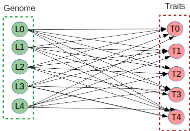

In the figure above, five loci $L_{i}$ are connected to each trait $T_{j}$ by arrows $X_{ij}$. Arrow values could be represented *within the genome*, as with the individual attributes `"X00"`, `"X01"`, `"X10"`, and `"X11"` in the toy example above. For a given desired covariance matrix of trait values, calculations of $X_{ij}$ become longer as trait number increases, but I should be able to write the code to get this for an arbitrary number of traits.

This is a simple way of doing things, but I think that it still leaves something to be desired. If we want the genetic covariances themselves to evolve (rather than just the traits via changing allele frequences in $L_{i}$), then we are forced to do it in a simplified way in which genetic covariances will almost inevitably evolve to become positive so that a ‘good’ value of $T0$ and $T1$ can be assured by a joint change with a change in $L0$ by modifying $X_{01}$ accordingly. In other words, any variation stuck into the genome that modifies $X_{ij}$ values can be done so that there is directional selection increasing the fitness of $T_{j}$ via change in $L_{i}$, I think. What we really want is to tangle things so that changes along the path from alleles to traits is more complex. Below is my initial plan for increasing the complexity in such a way as to make the genetic architecture itself evolve a bit more realistically.

**Adding some complexity**

I propose the addition of multiple hidden layers beween loci and traits, effectively building something resembling a [neural network](https://en.wikipedia.org/wiki/Artificial_neural_network) (see here for video), but perhaps loosely interpreting these layers as steps along biochemical or developmental pathways from alleles to traits affecting fitness.

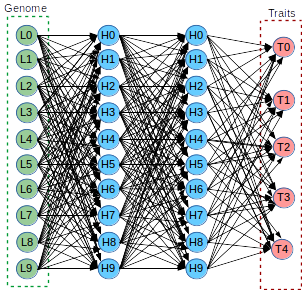

These hidden layers (blue) can now make each trait value a linear combination of all of the paths from each locus to each trait. For example, the value of $L0$ can now get to $T0$ in up to 100 different ways. Each link between nodes has its own value to modify the effect of a locus’ value on the end value of each trait. For example if the link from $L0 \to H0 = 0.5$, $H0 \to H0 = 0.5$, and $H0 \to T0 = -1$, then this one complete path causes $L0$ to decrease $T0$ by $L0(0.5 \times 0.5 \times -1) = -0.25L0$. This effect would then be **added to the effects** of all 99 other possible paths from $L0$ to $T0$ (I think it would probably make sense in the end to restrict values of edges to $0 \leq e_{i} \leq 1$; we could also fix some edge values to be zero, perhaps giving a more realistic network structure).

This looks like a mess, but that’s kind of the point. Having many paths from loci to traits should give us the freedom to allow genetic covariance to evolve *with some restrictions*. As with the example above, we can have values for the 250 edges that form the paths from loci to traits, but the hidden layers give us more flexibility in setting evolutionary constraints.

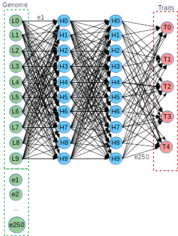

We could, for example, allow e1 to e250 above to be represented by potentially changing values in an individual’s genome (through mutation, selection, and drift). Given this, selection across all L0-L9 and e1-e250 would almost certainly rapidly increase fitness of all traits. But we could also, e.g., block mutation from happening at any of the hidden layers after initialising, e.g., e1-e200 to random values (i.e., alleles would have polygenic effects that potentially lead to fitness tradeoffs, but only parts or proportions of the genetic architecture that we want to evolve actually could). Or we could change the initial genetic variation or mutation rates of edges relative to loci (e.g., make the genetic architecture itself evolve more or less rapidly). We could then ask several potentially interesting questions by controlling the extent to which genetic covariances can evolve and how processes such as drift might affect loci that underly traits versus loci that underly covariance among traits.

To initialise a desired genetic covariance matrix, an evolutionary algorithm could be used. Basically, this would iteratively tweak the hidden layer edge values and check for a better or worse fit to the desired trait covariance matrix. The advantage of this would be that we could tell a function to build a genetic architecture that confroms to a covariance matrix without forcing it to specify *how* (i.e., the genetic architecture would be ‘found’ rather than imposed *a priori*, reducing the number of assumptions that we need to make).

Alternatively, I think it might be reasonable to introduce selection on traits by modelling a process of sequential invasion. That is, initialise all traits at some random value, but don’t immediately impose selection. Hence, the traits and the genetic architecture underlying them could be random and selectively neutral for a burn-in period before introducing some sort of selective pressure (e.g., after 100 generations of burn-in, feeding efficiency gets turned on such that there is selection on feeding efficiency for one crop, $T0$). One by one, new selection pressures could arise. This could avoid having to make the assumption that the genetic architecture evolves as a consequence of early simultaneous selection for multiple traits – it’s more realistic to assume that some traits arise and evolve first (e.g., the ability to feed on one crop), then a new selective pressure arise after an evolved genome and genetic architecture already exists.

> Update: 14 MAY 2019

**Plans for the full helicoverpa R package**

Given successful funding of the ENDORSE project, these notes will now continue in development of work package C1c of the project. The following very rough timeline is suggested.

This timeline is subject to revision, but the initial steps are more detailed planning for the software and model, with input from colleagues across all work packages.

> Update: 21 SEP 2018

**Success with the graphical display**

While I did not update this journal during its development very much, the [graphical display](http://r.rosemckeon.co.uk/helicoverpa/) looks really good, and received positive feedback from colleagues in Brazil.

**Simulations for Phase II**

While the toy model of the [graphical display](http://r.rosemckeon.co.uk/helicoverpa/) demonstrated the key points, a couple more functions are needed to do some initial simulations to get results to put in Phase II. First, new movement rules are needed for more realistic dispersal of *Helicoverpa* among cells. This is done now with the `toy_pois_move_pest` function. In the function below, for each pest, movement in a time step proceeds by (1) selecting how many jumps that the pest gets by sampling from a poisson distribution with mean `dist`, then moving up to `dist` cells away in any direction during each jump (uniform probability of all cells within `dist` of the original cell).

```r
# Simulate Poisson movement of toys -- a nasty loop here -- faster in C
toy_pois_move_pest <- function(PEST, LAND, dist = 1){
    pest_n   <- dim(PEST)[1];
    xlim     <- dim(LAND)[2];
    ylim     <- dim(LAND)[1];
    distance <- rpois(n = pest_n, lambda = dist);
    for(pest in 1:pest_n){
        move <- distance[pest];
        while(move > 0){
            move_x  <- sample(x = -move:move, size = 1);
            move_y  <- sample(x = -move:move, size = 1);
            PEST[pest, 3] <- PEST[pest, 3] + move_x;
            PEST[pest, 4] <- PEST[pest, 4] + move_y;
            move    <- move - 1;
        }
        while(PEST[pest, 3] < 1){
            PEST[pest, 3] <- PEST[pest, 3] + xlim;
        }
        while(PEST[pest, 3] > xlim){
            PEST[pest, 3] <- PEST[pest, 3] - xlim;
        }
        while(PEST[pest, 4] < 1){
            PEST[pest, 4] <- PEST[pest, 4] + ylim;
        }
        while(PEST[pest, 4] > ylim){
            PEST[pest, 4] <- PEST[pest, 4] - ylim;
        }
    }
    return(PEST);
}
```

We can check out the distribution of distance away from the original cell when the above function is implemented.

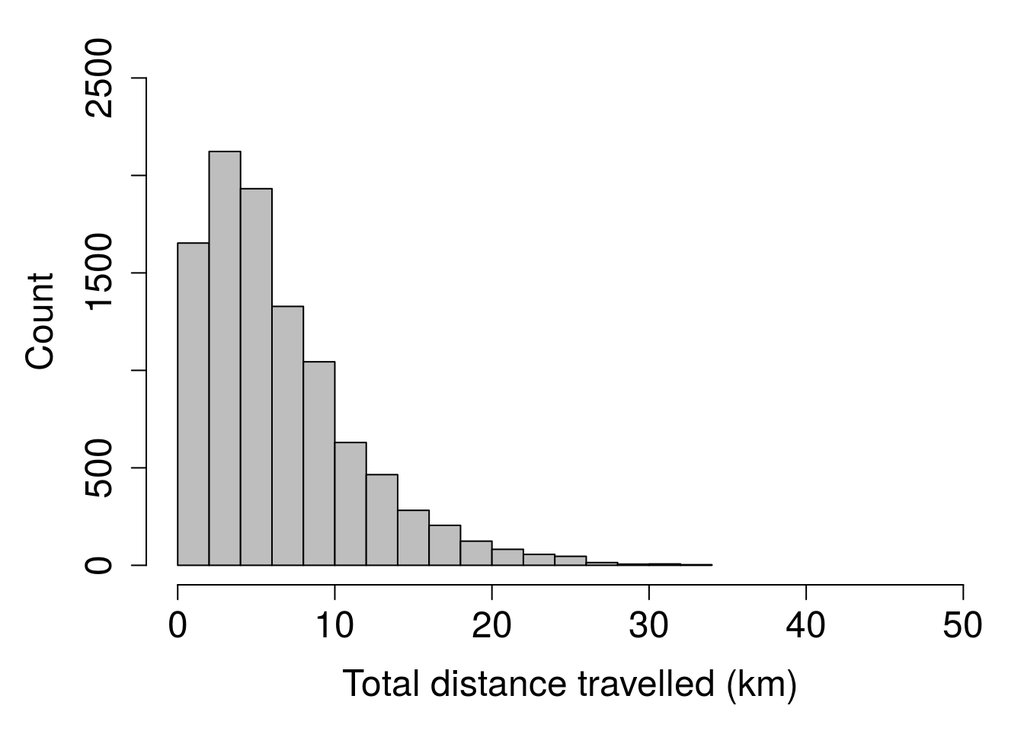

```r
LAND     <- toy_initialise_land(xdim = 50, ydim = 50, pathogens = 1, crops = 1);
PEST_1   <- toy_initialise_pest(LAND, N = 10000);
PEST_2   <- toy_pois_move_pest(PEST_1, LAND, dist = 5);
diffx_1  <- (PEST_1[,3] - PEST_2[,3])^2;
diffx_2  <- (PEST_1[,3] - PEST_2[,3] + 50)^2; # Account for the torus
diffx_3  <- (PEST_1[,3] - PEST_2[,3] - 50)^2;
diffy_1  <- (PEST_1[,4] - PEST_2[,4])^2;
diffy_2  <- (PEST_1[,4] - PEST_2[,4] + 50)^2; # Account for the torus
diffy_3  <- (PEST_1[,4] - PEST_2[,4] - 50)^2;
diffx    <- rep(x = 0, times = 10000);
diffy    <- rep(x = 0, times = 10000);
for(i in 1:10000){ # Assuming no one goes too far
    diffx[i] <- min(c(diffx_1[i], diffx_2[i], diffx_3[i]));
    diffy[i] <- min(c(diffy_1[i], diffy_2[i], diffy_3[i]));
}
dist_mv1 <- sqrt(diffx + diffy);
par(mar = c(5, 5, 2, 1));
hist(dist_mv1, main = "", col = "grey", cex.lab = 1.5, cex.axis = 1.5,
     xlab = "Total distance travelled (km)", ylab = "Count",
     ylim = c(0, 2500), xlim = c(0, 50));
```

The next part is to initialise the land in blocks so that we can control how big of an area is deadicated toward a paricular fungal biopesticide and crop area. We want to be able to control how many blocks are put down over the landscape. The code below does this, albeit in not the most efficient way.

```r
toy_block_land <- function(xdim, ydim, pathogens, crops, block_len){
    cells     <- xdim * ydim;
    cell_left <- cells %% (block_len * block_len);
    if(cell_left > 0){
        stop("Landscape cannot be divided into squares of size 'block_len'");
    }
    LAND      <- array(data = 0, dim = c(xdim, ydim, 3));
    tx0       <- 1;
    tx1       <- block_len;
    ty0       <- 1;
    ty1       <- block_len;
    block_num <- 1;
    while(tx0 <= xdim & ty0 <= ydim){
        LAND[tx0:tx1, ty0:ty1, 1] <- block_num;
        tx0                       <- tx1 + 1;
        tx1                       <- tx1 + block_len;
        if(tx0 > xdim){
            tx0 <- 0;
            tx1 <- block_len;
            ty0 <- ty1 + 1;
            ty1 <- ty1 + block_len;
        }
        block_num <- block_num + 1;
    }
    block_num  <- block_num - 1;
    for(block in 1:block_num){
        rand_path <- sample(x = 1:pathogens, size = 1);
        rand_crop <- sample(x = 1:crops, size = 1);
        for(xx in 1:xdim){
            for(yy in 1:ydim){
                if(LAND[xx, yy, 1] == block){
                    LAND[xx, yy, 2] <- rand_path;
                    LAND[xx, yy, 3] <- rand_crop;
                }
            }
        }
    }
    return(LAND);
}
```

One reason I don’t mind all of the loops in the toy model is that they will need to be used when this is translated to C – there’s not really a way around it (I don’t think), so there’s no reason to worry too much about making everything elegant and avoiding R loops. It does take a while for landscapes to be initialised in the toy model, but not nearly as long as it takes most generations to run (at least, not ones with lots of pests). Here are some ways of using `toy_block_land` to make landscapes. I’ll show fungal biopesticide blocks being put down randomly below

**Block length 1**: Each cell is its own block, corresponding to applying fungal biopesticides in each 1 km by 1 km square on the landscape.

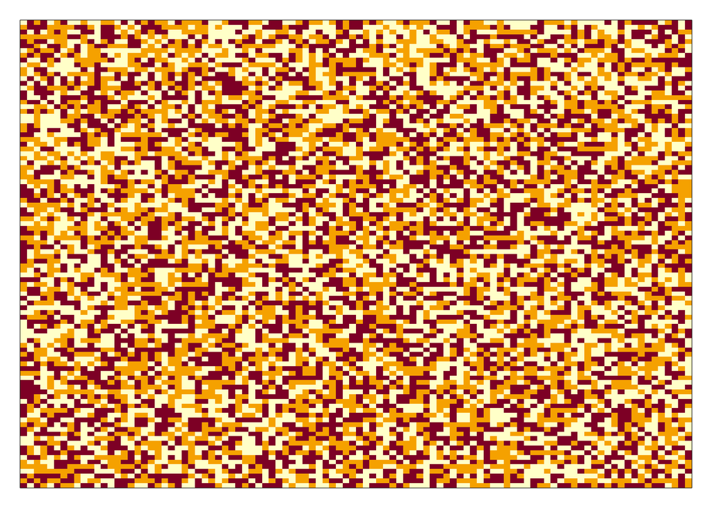

```r
LAND1 <- toy_block_land(xdim = 100, ydim = 100, pathogens = 3, crops = 3,
                        block_len = 1);
par(mar = c(1, 1, 1, 1));
image(LAND1[,,2], xaxt = "n", yaxt = "n");
```

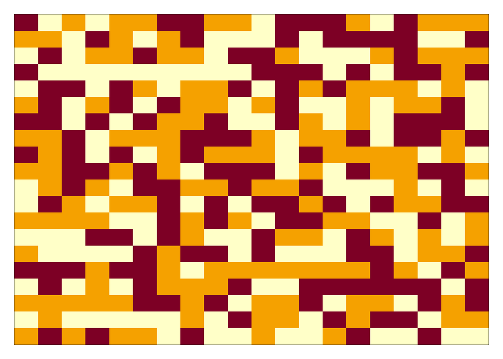

```r
LAND5 <- toy_block_land(xdim = 100, ydim = 100, pathogens = 3, crops = 3,
                        block_len = 5);
par(mar = c(1, 1, 1, 1));
image(LAND5[,,2], xaxt = "n", yaxt = "n");
```

**Block length 10**: Each cell is its own block, corresponding to applying fungal biopesticides in each 10 km by 10 km square on the landscape.

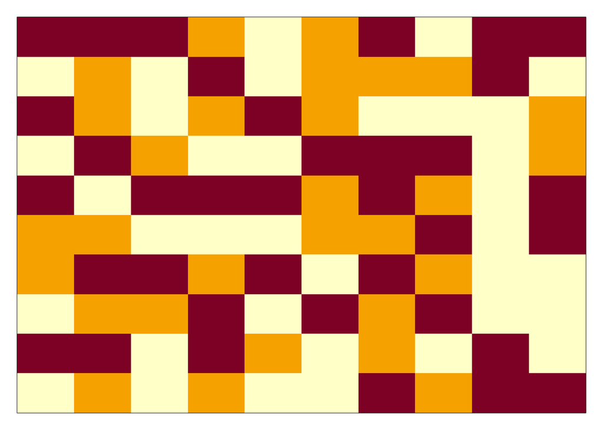

```r
LAND10 <- toy_block_land(xdim = 100, ydim = 100, pathogens = 3, crops = 3,
                        block_len = 10);
par(mar = c(1, 1, 1, 1));
image(LAND10[,,2], xaxt = "n", yaxt = "n");
```

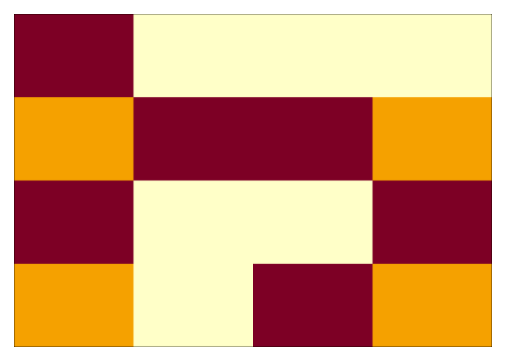

```r
LAND25 <- toy_block_land(xdim = 100, ydim = 100, pathogens = 3, crops = 3,
                        block_len = 25);
par(mar = c(1, 1, 1, 1));
image(LAND25[,,2], xaxt = "n", yaxt = "n");
```

Of course, for even the Phase II toy simulations, we’ll want a bigger landscape. I’ll try to do this for 1000 km by 1000 km and see how it goes.

> Update: 27 AUG 2018

**Update to transferring to JSON**

The function below has now been modified, along with the outer function for simulating resistance.

```r
toy_simulate_resistance <- function(generations = 20,       # Generations to sim
                                    xdim = 2,               # Land dimension 1
                                    ydim = 2,               # Land dimension 2
                                    pathogens = 1,          # Pathogen strains
                                    crops = 1,              # Crop species
                                    path_alleles = 3,       # Pathogen alleles
                                    crop_alleles = 3,       # Crop alleles
                                    pest_init = 2000,       # Initial pests
                                    crop_rotate = "static", # Crops rotated
                                    path_rotate = "static", # Pathogens rotated
                                    pest_move_pr = 0.1,     # Pest movement
                                    pest_move_dist = 1,     # Pest move distance
                                    fecundity = 8,          # Offspring per fem
                                    cell_K = 2000           # K per cell
                                    ){

    if(pest_move_dist > xdim & pest_move_dist > ydim){
        pest_move_dist <- max(c(xdim, ydim)); # Avoids error
    }
    # Start initialising the landscape and pests
    LAND <- toy_initialise_land(xdim  = xdim, ydim = ydim,
                                pathogens = pathogens, crops = crops);
    PEST <- toy_initialise_pest(LAND, N = pest_init, p_al = path_alleles,
                                c_al = crop_alleles);
    # Start the generations
    PEST_DATA   <- NULL;
    LAND_DATA   <- NULL;
    gen         <- 1;
    while(gen < generations){
        LAND <- toy_set_crops(LAND, crops, crop_rotate);
        LAND <- toy_set_paths(LAND, pathogens, path_rotate);
        PEST <- toy_move_pest(PEST, LAND, pest_move_pr, pest_move_dist);
        PEST <- toy_feed_pest(PEST, LAND);
        if(toy_check_extinction(PEST, gen) == TRUE){ # Hate these if breaks here
            break;
        }
        PEST <- toy_kill_pest(PEST, LAND);
        if(toy_check_extinction(PEST, gen) == TRUE){
            break;
        }
        PEST <- toy_reproduce_pest(PEST, LAND, path_alleles, crop_alleles,
                                   fecundity, cell_K);
        if(toy_check_extinction(PEST, gen) == TRUE){
            break;
        }
        PEST_DATA[[gen]] <- PEST;
        LAND_DATA[[gen]] <- LAND;
        gen <- gen + 1;
    }
    return(list(PEST_DATA = PEST_DATA, LAND_DATA = LAND_DATA));
}

results_to_json <- function(pest, land, printit = TRUE, filename = "sim.json"){
    if("package:jsonlite" %in% search() == FALSE){
        stop("Error: Need to load the R package 'jsonlite'")
    }
    inds   <- dim(pest)[1];
    p_geno <- rep(x = 0, times = inds);
    c_geno <- rep(x = 0, times = inds);
    path   <- rep(x = 0, times = inds);
    crop   <- rep(x = 0, times = inds);
    r_path <- rep(x = 0, times = inds);
    r_crop <- rep(x = 0, times = inds);
    for(i in 1:inds){ # Doing this a bit lazily, without refactoring the rest
        p_geno[i] <- as.numeric( paste(pest[i,5], pest[i,6], sep = ""));
        c_geno[i] <- as.numeric( paste(pest[i,7], pest[i,8], sep = ""));
        xloc      <- pest[i, 3];
        yloc      <- pest[i, 4];
        path[i]   <- land[xloc, yloc, 2];
        crop[i]   <- land[xloc, yloc, 3];
        if(pest[i,5] == path[i] | pest[i,5] == path[i]){
            r_path <- 1;
        }
        if(pest[i,7] == crop[i] | pest[i,8] == crop[i]){
            r_crop <- 1;
        }
    }
    data      <- matrix(data = 0, nrow = inds, ncol = 10);
    data[,1]  <- pest[,1];
    data[,2]  <- pest[,2];
    data[,3]  <- pest[,3];
    data[,4]  <- pest[,4];
    data[,5]  <- path;
    data[,6]  <- crop;
    data[,7]  <- p_geno;
    data[,8]  <- c_geno;
    data[,9]  <- r_path;
    data[,10] <- r_crop;
    colnames(data) <- c("ID", "sex", "xloc", "yloc", "path", "crop",
                        "p_geno", "c_geno", "resist_path", "eat_crop");
    modsim <- list( traits = colnames(data),
                    values = unname(apply(data, 1,
                                          function(x) as.data.frame(t(x))))
    );
    sim_json <- toJSON(list(traits = names(modsim), values = modsim),
                       pretty = TRUE);
    if(printit == TRUE){
        write(sim_json, filename);
    }
    return(sim_json);
}
```

We can run things the same way to generate the output. Note that the output from `toy_simulate_resistance` has changed, so now we need to read the list into `results_to_json`. The list contains the elements `PEST_DATA` and `LAND_DATA`.

```r
library(jsonlite);
sim  <- toy_simulate_resistance(pathogens = 3, crops = 3);
json <- results_to_json(pest = sim$PEST_DATA[[19]], land = sim$LAND_DATA[[19]],
                        filename = "../data/sample_sim.json");
```

The output is here.

**Transferring simulation results to json**

I’ve written a short bit of code to link the simulation results to the code. The input for this is a single *generation* of the model (this could be easily changed). So if we run the `toy_simulate_resistance` function as before, we get a list with elements being each generation.

```r
sim <- toy_simulate_resistance(crops = 3, pathogens = 3);
```

We can look at just the last generation below.

```r
head(sim[[19]]);
```

```
##        [,1] [,2] [,3] [,4] [,5] [,6] [,7] [,8]
## [1,] 139227    1    1    1    3    3    2    3
## [2,] 139228    1    1    1    3    1    1    2
## [3,] 139229    1    1    1    3    3    2    2
## [4,] 139230    1    1    1    3    3    2    2
## [5,] 139231    0    1    1    3    3    2    1
## [6,] 139232    1    1    1    3    3    2    1
```

The code below sticks all of this into the json format (for the one generation), prints the json output to a file if `printit == TRUE`, and returns the json output.

```r
results_to_json <- function(sim, printit = TRUE, filename = "sim.json"){
    if("package:jsonlite" %in% search() == FALSE){
        stop("Error: Need to load the R package 'jsonlite'")
    }
    colnames(sim) <- c("ID", "sex", "xloc", "yloc", "p_al_1", "p_al_2",
                       "c_al_1", "c_al_2");
    modsim <- list( traits = colnames(sim),
                    values = unname(apply(sim, 1,
                                          function(x) as.data.frame(t(x))))
              );
    sim_json <- toJSON(list(traits = names(modsim), values = modsim),
                   pretty = TRUE);
    if(printit == TRUE){
        write(sim_json, filename);
    }
    return(sim_json);
}
```

Using the function below to print and return the json. This relies on the `jsonlite` package, which must be installed and loaded.

```r
library(jsonlite);
sim_json <- results_to_json(sim = sim[[19]],
                            filename = "../data/sample_sim.json");
```

The `sim_json` output should be easy to modify as necessary. I’ve not added it here because it’s much too large for the notebook, but it can be accessed on the dev branch in the file sample_sim.json.

> Update: 14 AUG 2018

**More playing around with the toy model**

Following up on yesterday, I have tweaked two functions to allow us to manipulate the number of alleles underlying pathogen resistance and crop feeding. In effect, this allows us to see how selection can sweep through to nearly fix an allele for resistance to a particular pathogen or for feeding on a particular crop (since only one allele is needed, other neutral alleles can hide in the heterozygotes). But, when crops are rotated, or pathogens are rotated, we have higher genetic diversity – note that we are making an implicit assumption of a strong negative genetic correlation; pests can only have two alleles for resistance, e.g., and if there are three pathogens, then all pests must necessarily be susceptible to 1-2 pathogens.

```r
# ==============================================================================
# This is just a toy version of the model, for the presentation
# ==============================================================================
# Note that I'm adding 'toy' at the start of each function; this is just in case
# we actually want to keep some of these functions in the eventual R package,
# but also don't want to worry about not being able to name functions like
# "initialise_land" the same here as elsewhere in the eventual bigger model.
# ==============================================================================
toy_simulate_resistance <- function(generations = 20,       # Generations to sim
                                    xdim = 2,               # Land dimension 1
                                    ydim = 2,               # Land dimension 2
                                    pathogens = 1,          # Pathogen strains
                                    crops = 1,              # Crop species
                                    path_alleles = 3,       # Pathogen alleles
                                    crop_alleles = 3,       # Crop alleles
                                    pest_init = 2000,       # Initial pests
                                    crop_rotate = "static", # Crops rotated
                                    path_rotate = "static", # Pathogens rotated
                                    pest_move_pr = 0.1,     # Pest movement
                                    pest_move_dist = 1,     # Pest move distance
                                    fecundity = 8,          # Offspring per fem
                                    cell_K = 2000           # K per cell
                                    ){

    if(pest_move_dist > xdim & pest_move_dist > ydim){
        pest_move_dist <- max(c(xdim, ydim)); # Avoids error
    }
    # Start initialising the landscape and pests
    LAND <- toy_initialise_land(xdim  = xdim, ydim = ydim,
                                pathogens = pathogens, crops = crops);
    PEST <- toy_initialise_pest(LAND, N = pest_init, p_al = path_alleles,
                                c_al = crop_alleles);
    # Start the generations
    PEST_DATA   <- NULL;
    gen         <- 1;
    while(gen < generations){
        LAND <- toy_set_crops(LAND, crops, crop_rotate);
        LAND <- toy_set_paths(LAND, pathogens, path_rotate);
        PEST <- toy_move_pest(PEST, LAND, pest_move_pr, pest_move_dist);
        PEST <- toy_feed_pest(PEST, LAND);
        if(toy_check_extinction(PEST, gen) == TRUE){ # Hate these if breaks here
            break;
        }
        PEST <- toy_kill_pest(PEST, LAND);
        if(toy_check_extinction(PEST, gen) == TRUE){
            break;
        }
        PEST <- toy_reproduce_pest(PEST, LAND, path_alleles, crop_alleles,
                                   fecundity, cell_K);
        if(toy_check_extinction(PEST, gen) == TRUE){
            break;
        }
        PEST_DATA[[gen]] <- PEST;
        gen <- gen + 1;
    }
    return(PEST_DATA);
}

summarise_pest_data <- function(PEST_DATA){
    # Density estimates
    den_list  <- unlist(lapply(PEST_DATA, dim));
    den_vect  <- den_list[c(TRUE, FALSE)];
    gens      <- length(PEST_DATA);
    p_alleles <- max(c(PEST_DATA[[1]][,5], PEST_DATA[[1]][,6]));
    c_alleles <- max(c(PEST_DATA[[1]][,7], PEST_DATA[[1]][,8]));
    p_tabl    <- matrix(data = 0, nrow = gens, ncol = p_alleles);
    c_tabl    <- matrix(data = 0, nrow = gens, ncol = c_alleles);
    # Allele frequencies
    for(gen in 1:length(PEST_DATA)){
        total_p_alleles <- length(PEST_DATA[[gen]][,5:6]);
        total_c_alleles <- length(PEST_DATA[[gen]][,7:8]);
        for(allele in 1:p_alleles){
            allele_count         <- sum(PEST_DATA[[gen]][,5:6] == allele);
            p_tabl[gen, allele]  <- allele_count / total_p_alleles
        }
        for(allele in 1:c_alleles){
            allele_count         <- sum(PEST_DATA[[gen]][,7:8] == allele);
            c_tabl[gen, allele]  <- allele_count / total_c_alleles
        }
    }
    return(list(densities = den_vect, pathogen_fr = p_tabl, crop_fr = c_tabl));
}
```

I’m going to run the same analysis as yesterday, but now show how allele frequencies change over generations. I’ve not broken this down by landscape cell yet, but this will be easy to do (just let me know the format the data would be best presented in). In each case, now there will be 3 alleles underlying pathogen resistance, and 3 alleles underlying crop feeding.

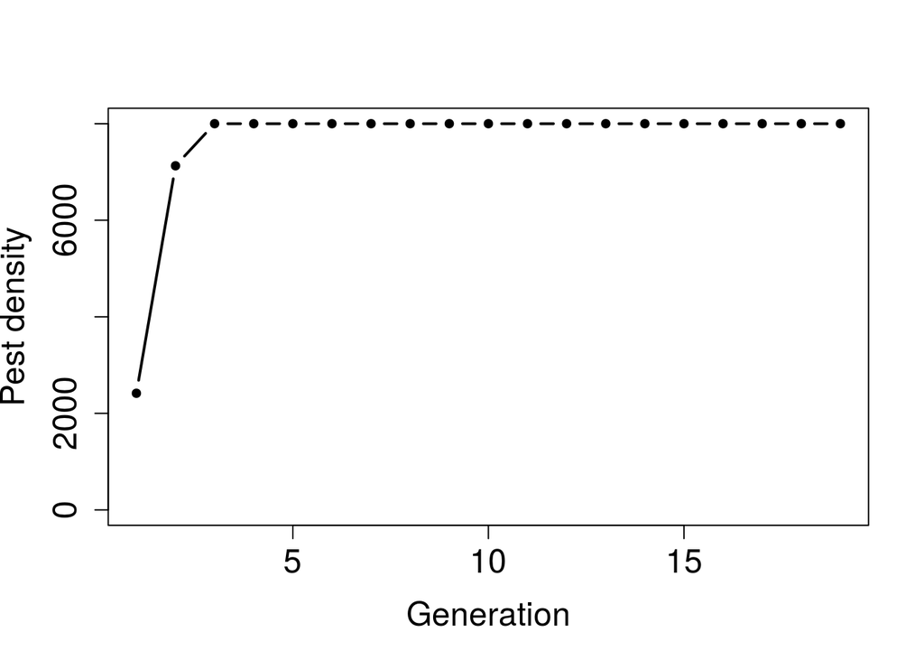

```r
sim1 <- toy_simulate_resistance(pathogens = 1, crops = 1, cell_K = 2000,
                                pest_init = 2000, fecundity = 8,
                                generations = 20, pest_move_pr = 0.1,
                                crop_rotate = "static", path_rotate = "static");
dat1 <- summarise_pest_data(sim1);
plot(x = 1:length(dat1$densities), y = dat1$densities, type = "b", pch = 20,
     lwd = 2, cex.lab = 1.5, cex.axis = 1.5, ylim = c(0, 8000), xlim = c(1, 19),
     xlab = "Generation", ylab = "Pest density");
```

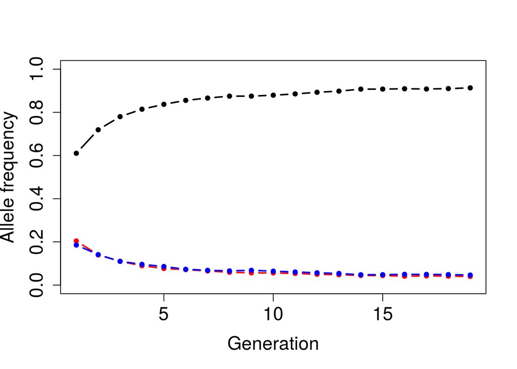

```r
plot(x = 1:length(dat1$pathogen_fr[,1]), y = dat1$pathogen_fr[,1], type = "b",
     pch = 20, lwd = 2, cex.lab = 1.5, cex.axis = 1.5, ylim = c(0, 1),
     xlim = c(1, 19), xlab = "Generation", ylab = "Allele frequency");
points(x = 1:length(dat1$pathogen_fr[,2]), y = dat1$pathogen_fr[,2], type = "b",
     pch = 20, lwd = 2, col = "red");
points(x = 1:length(dat1$pathogen_fr[,3]), y = dat1$pathogen_fr[,3], type = "b",
     pch = 20, lwd = 2, col = "blue");
```

Next, we can see what happens when we instead have 3 pathogens under otherwise identical conditions. In each generation, one of three pathogens is randomly applied to each landscape cell.

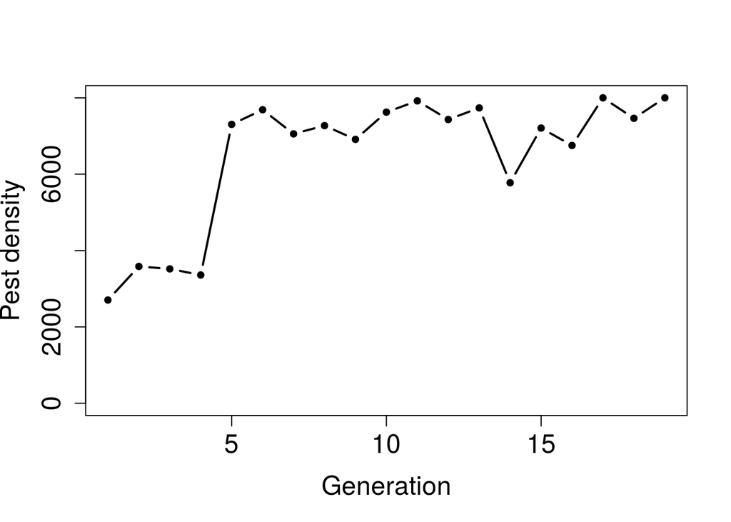

```r
sim2 <- toy_simulate_resistance(pathogens = 3, crops = 1, cell_K = 2000,
                                pest_init = 2000, fecundity = 8,
                                generations = 20, pest_move_pr = 0.1,
                                crop_rotate = "static", path_rotate = "random");
dat2 <- summarise_pest_data(sim2);
plot(x = 1:length(dat2$densities), y = dat2$densities, type = "b", pch = 20,
     lwd = 2, cex.lab = 1.5, cex.axis = 1.5, ylim = c(0, 8000), xlim = c(1, 19),
     xlab = "Generation", ylab = "Pest density");
```

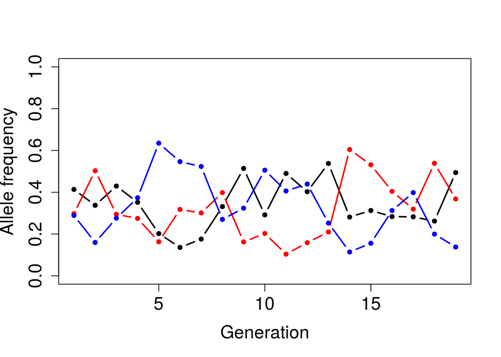

```r
plot(x = 1:length(dat2$pathogen_fr[,1]), y = dat2$pathogen_fr[,1], type = "b",
     pch = 20, lwd = 2, cex.lab = 1.5, cex.axis = 1.5, ylim = c(0, 1),
     xlim = c(1, 19), xlab = "Generation", ylab = "Allele frequency");
points(x = 1:length(dat2$pathogen_fr[,2]), y = dat2$pathogen_fr[,2], type = "b",
     pch = 20, lwd = 2, col = "red");
points(x = 1:length(dat2$pathogen_fr[,3]), y = dat2$pathogen_fr[,3], type = "b",
     pch = 20, lwd = 2, col = "blue");
```

Next, we can see what happens when we instead have 3 pathogens *and* 3 crops under otherwise identical conditions. In each generation, one of three pathogens and one of three crops are randomly applied to each landscape cell.

```r
sim3 <- toy_simulate_resistance(pathogens = 3, crops = 3, cell_K = 2000,
                                pest_init = 2000, fecundity = 8,
                                generations = 20, pest_move_pr = 0.1,
                                crop_rotate = "random", path_rotate = "random");
```

```
## [1] "Extinction occurred in generation 14"
```

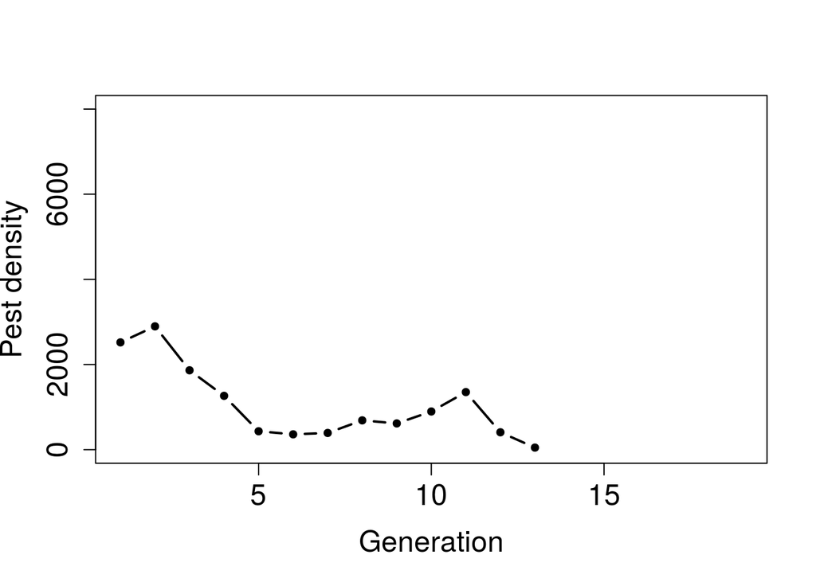

```r
dat3 <- summarise_pest_data(sim3);
plot(x = 1:length(dat3$densities), y = dat3$densities, type = "b", pch = 20,
     lwd = 2, cex.lab = 1.5, cex.axis = 1.5, ylim = c(0, 8000), xlim = c(1, 19),
     xlab = "Generation", ylab = "Pest density");
```

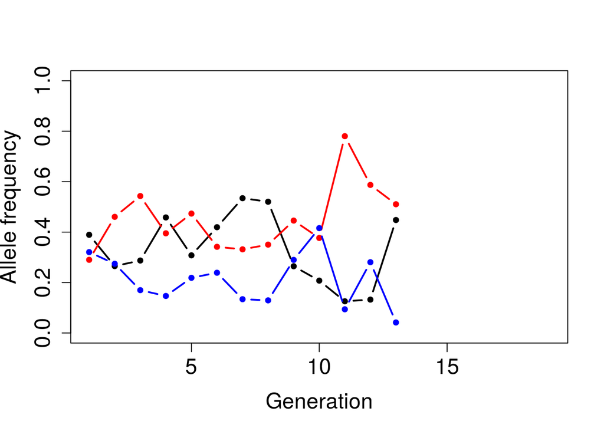

```r
plot(x = 1:length(dat3$pathogen_fr[,1]), y = dat3$pathogen_fr[,1], type = "b",
     pch = 20, lwd = 2, cex.lab = 1.5, cex.axis = 1.5, ylim = c(0, 1),
     xlim = c(1, 19), xlab = "Generation", ylab = "Allele frequency");
points(x = 1:length(dat3$pathogen_fr[,2]), y = dat3$pathogen_fr[,2], type = "b",
     pch = 20, lwd = 2, col = "red");
points(x = 1:length(dat3$pathogen_fr[,3]), y = dat3$pathogen_fr[,3], type = "b",
     pch = 20, lwd = 2, col = "blue");
```

As is evident, pathogen and crop rotation decreases pest density and increases the diversity of alleles underlying pathogen resistance and crop feeding.

> Update: 13 AUG 2018

**Visual stuff looks good!**

Rose has created a very nice [visual display](http://r.rosemckeon.co.uk/helicoverpa/) of the landscape, with sliders allowing for multiple crop species and pathogen strains.

**Toy model prototype**

I have managed to complete a toy model today, which should be sufficient to produce the simulated data needed to get the key ideas across. I’m going to dump the code below, which is located in the toy_model.R data file, not yet pushed on to master. We’ll need to merge the interface branch with the dev branch soon, which should be easy enough. The whole thing is in R, and includes all of the basic steps from the code structure mentioned on 30 JUL 2018, including mutation, recombination, dispersal, and pathogen and crop rotation (random or sequential). The output isn’t in that helpful of a form yet, but it will get there soon. To skip the many lines of code from the toy_model.R file, go here.

To quickly summarise, there are 12 parameters we can play with in the toy simulation model:

1. Number of generations to simulate (`generations`)
2. X dimension (longitude), i.e., cell number, on the landscape (`xdim`)
3. Y dimension (latitude), i.e., cell number, on the landscape (`ydim`)
4. Total number of pathogen strains that can be applied (`pathogens`)
5. Total number of crops that can be planted (`crops`)
6. Initial number of pests (`pest_init`)
7. How to rotate crops on the landscape (`crop_rotate`: where `crop_rotate = "static"` means don’t rotate between generations, `crop_rotate = "rotate"` means sequence through each crop one at a time over generations, and `crop_rotate = "random"` means apply a random crop in each generation – all done independently for each landscape cell)
8. How to rotate pathogen application on the landscape (`path_rotate`: where `path_rotate = "static"` means don’t rotate between generations, `path_rotate = "rotate"` means sequence through each pathogen one at a time over generations, and `path_rotate = "random"` means apply a random pathogen in each generation – all done independently for each landscape cell)
9. Probability that a pest will move to a new cell in the generation (`pest_move_pr`)
10. Distance a pest will move up to in any direction from its natal cell (`pest_move_dist`; note, the landscape is a torus, and there is therefore no edge – pests that move off of one side end up on the other)
11. Number of offspring each *female* pest produces (`fecundity`)
12. Carrying capacity of pests *per cell* (`cell_K`)

Default parameter values are shown below. Note that the model is an individual-based simulation with an *extremely* simple diploid genetic architecture with two loci (one for pathogens, and one for crops). If there are $N$ pathogens, then there are $N$ alleles for pathogen resistance, and pests must have at least one allele to resist (else they die). Similarly, if there are $N$ crops, then there are $N$ alleles for being able to eat crops, and pests must have at least one to eat (else they die).

```r
toy_simulate_resistance <- function(generations = 20,       # Generations to sim
                                    xdim = 2,               # Land dimension 1
                                    ydim = 2,               # Land dimension 2
                                    pathogens = 1,          # Pathogen strains
                                    crops = 1,              # Crop species
                                    pest_init = 2000,       # Initial pests
                                    crop_rotate = "static", # Crops rotated
                                    path_rotate = "static", # Pathogens rotated
                                    pest_move_pr = 0.1,     # Pest movement
                                    pest_move_dist = 1,     # Pest move distance
                                    fecundity = 8,          # Offspring per fem
                                    cell_K = 2000           # K per cell
                                    ){

    if(pest_move_dist > xdim & pest_move_dist > ydim){
        pest_move_dist <- max(c(xdim, ydim)); # Avoids error
    }
    # Start initialising the landscape and pests
    LAND <- toy_initialise_land(xdim  = xdim, ydim = ydim,
                                pathogens = pathogens, crops = crops);
    PEST <- toy_initialise_pest(LAND, N = pest_init, p_al = pathogens,
                                c_al = crops);
    # Start the generations
    PEST_DATA   <- NULL;
    gen         <- 1;
    while(gen < generations){
        LAND <- toy_set_crops(LAND, crops, crop_rotate);
        LAND <- toy_set_paths(LAND, pathogens, path_rotate);
        PEST <- toy_move_pest(PEST, LAND, pest_move_pr, pest_move_dist);
        PEST <- toy_feed_pest(PEST, LAND);
        if(toy_check_extinction(PEST, gen) == TRUE){ # Hate these if breaks here
            break;
        }
        PEST <- toy_kill_pest(PEST, LAND);
        if(toy_check_extinction(PEST, gen) == TRUE){
            break;
        }
        PEST <- toy_reproduce_pest(PEST, LAND, pathogens, crops, fecundity,
                                   cell_K);
        if(toy_check_extinction(PEST, gen) == TRUE){
            break;
        }
        PEST_DATA[[gen]] <- PEST;
        gen <- gen + 1;
    }
    return(PEST_DATA);
}

summarise_pest_data <- function(PEST_DATA){
    # Density estimates
    den_list <- unlist(lapply(PEST_DATA, dim));
    den_list <- den_list[c(TRUE, FALSE)];
    return(den_list);
}

toy_check_extinction <- function(PEST, gen){
    if(is.vector(PEST) == TRUE){
        print(paste("Extinction occurred in generation", gen));
        return(TRUE);
    }
    if(dim(PEST)[1] < 4){
        print(paste("Extinction occurred in generation", gen));
        return(TRUE);
    }
    if(sum(PEST[,2] == 0) < 1 | sum(PEST[,2] == 1) < 1){
        print(paste("Extinction occurred in generation", gen));
        return(TRUE);
    }
    return(FALSE);
}

# Initialise the landscape
toy_initialise_land <- function(xdim = 2, ydim = 2, pathogens = 1, crops = 1){
    LAND      <- array(data = 0, dim = c(xdim, ydim, 3));
    p_values  <- sample(x = 1:pathogens, size = xdim * ydim, replace = TRUE);
    p_layer   <- matrix(data = p_values, ncol = xdim, nrow = ydim);
    c_values  <- sample(x = 1:crops, size = xdim * ydim, replace = TRUE);
    c_layer   <- matrix(data = c_values, ncol = xdim, nrow = ydim);
    LAND[,,2] <- p_layer; # Just occurred to me that we might want a layer for
    LAND[,,3] <- c_layer; # carrying capacity of the cell in LAND later
    return(LAND);
}

# Initialise some *very* simple pests. Each allele is just going to map one to
# one for whether a crop can be attacked or a pathogen resisted. I am not even
# going to add traits affecting dispersal in the toy version -- this can be
# uniform for all individuals
toy_initialise_pest <- function(LAND, N = 10, p_al = 1, c_al = 1){
    xdim     <- dim(LAND)[1]; # This is needed to put the pests on some
    ydim     <- dim(LAND)[2]; # landscape cell
    PEST     <- matrix(data = 0, nrow = N, ncol = 8);
    PEST[,1] <- 1:N;                                           # ID
    PEST[,2] <- sample(x = c(0, 1), size = N, replace = TRUE); # Sex
    PEST[,3] <- sample(x = 1:xdim,  size = N, replace = TRUE); # x-location
    PEST[,4] <- sample(x = 1:ydim,  size = N, replace = TRUE); # y-location
    PEST[,5] <- sample(x = 1:p_al,  size = N, replace = TRUE); # p allele 1
    PEST[,6] <- sample(x = 1:p_al,  size = N, replace = TRUE); # p allele 2
    PEST[,7] <- sample(x = 1:c_al,  size = N, replace = TRUE); # c allele 1
    PEST[,8] <- sample(x = 1:c_al,  size = N, replace = TRUE); # c allele 2
    return(PEST);
}

# Just going to make this a simple function at first, randomly changing crops
toy_set_crops <- function(LAND, crops = 1, type = "static"){
    if(crops == 1 | type == "static"){
        return(LAND);
    }
    if(type == "rotate"){
        old_crop                   <- LAND[,,3];
        new_crop                   <- old_crop + 1;
        new_crop[new_crop > crops] <- 1;
        LAND[,,3]                  <- new_crop;
    }else{ # Else it just randomises -- can think about fancier ways later
        xdim      <- dim(LAND)[1];
        ydim      <- dim(LAND)[2];
        new_cval  <- sample(x = 1:crops, size = xdim * ydim, replace = TRUE);
        new_crop  <- matrix(data = new_cval, nrow = xdim, ncol = ydim);
        LAND[,,3] <- new_crop;
    }
    return(LAND);
}

# Ditto here -- just a simple function changing pathogens
toy_set_paths <- function(LAND, paths = 1, type = "static"){
    if(paths == 1 | type == "static"){
        return(LAND);
    }
    if(type == "rotate"){
        old_path                   <- LAND[,,3];
        new_path                   <- old_path + 1;
        new_path[new_path > paths] <- 1;
        LAND[,,2]                  <- new_path;
    }else{ # Else it just randomises -- can think about fancier ways later
        xdim      <- dim(LAND)[1];
        ydim      <- dim(LAND)[2];
        new_pval  <- sample(x = 1:paths, size = xdim * ydim, replace = TRUE);
        new_path  <- matrix(data = new_pval, nrow = xdim, ncol = ydim);
        LAND[,,2] <- new_path;
    }
    return(LAND);
}
```

```r
# Just a function to move pests at a given value, randomly on the landscape. The
# `prob` is just probability of moving in a time step, while `dist` is just the
# maximum distance moved in cells, in any direction.
toy_move_pest <- function(PEST, LAND, prob = 0.1, dist = 1){
    xdim                     <- dim(LAND)[1];
    ydim                     <- dim(LAND)[2];
    pests                    <- dim(PEST)[1];
    to_move                  <- rbinom(n = pests, size = 1, pr = prob);
    move_x                   <- sample(x = -dist:dist, size = pests,
                                       replace = TRUE);
    move_y                   <- sample(x = -dist:dist, size = pests,
                                       replace = TRUE);
    PEST[to_move == 1, 3]    <- PEST[to_move == 1, 3] + move_x[to_move == 1];
    PEST[to_move == 1, 4]    <- PEST[to_move == 1, 4] + move_y[to_move == 1];
    # The ifs below make a torus landscape so that pests don't move off of it
    # In C, this will be done with a loop that looks cleaner; the below is just
    # avoiding using a loop in R, though it would probably be fine.
    if(length(PEST[PEST[,3] < 1, 3]) > 0){
        PEST[PEST[,3] < 1, 3] <- PEST[PEST[,3] < 1, 3] + xdim;
    }
    if(length(PEST[PEST[,3] > xdim, 3]) > 0){
        PEST[PEST[,3] > xdim, 3] <- PEST[PEST[,3] > xdim, 3] - xdim;
    }
    if(length(PEST[PEST[,4] < 1, 4]) > 0){
        PEST[PEST[,4] < 1, 4] <- PEST[PEST[,4] < 1, 4] + ydim;
    }
    if(length(PEST[PEST[,4] > ydim, 4]) > 0){
        PEST[PEST[,4] > ydim, 4] <- PEST[PEST[,4] > ydim, 4] - ydim;
    }
    return(PEST);
}

# Need to now feed the pests and remove those that don't feed (crop unavailable)
toy_feed_pest <- function(PEST, LAND){
    # I'm just going to use a loop here, else matching to LAND cells is rough
    pests <- dim(PEST)[1];
    eaten <- rep(x = 0, times = pests);
    for(i in 1:pests){
        x_loc <- PEST[i, 3];
        y_loc <- PEST[i, 4];
        food  <- LAND[x_loc, y_loc, 3];
        if(PEST[i, 7] == food | PEST[i, 8] == food){
            eaten[i] <- 1;
        }
    }
    PEST <- PEST[eaten == 1,]; # You don't eat, you don't live
    return(PEST);
}

# Then need to have pests resist pathogens, kill those that cannot
toy_kill_pest <- function(PEST, LAND){
    # I'm just going to use a loop here, else matching to LAND cells is rough
    pests    <- dim(PEST)[1];
    survived <- rep(x = 0, times = pests);
    for(i in 1:pests){
        x_loc <- PEST[i, 3];
        y_loc <- PEST[i, 4];
        patho <- LAND[x_loc, y_loc, 2];
        if(PEST[i, 5] == patho | PEST[i, 6] == patho){
            survived[i] <- 1;
        }
    }
    PEST <- PEST[survived == 1,]; # You don't eat, you don't live
    return(PEST);
}

# Then, reproduce pests that are left
toy_reproduce_pest <- function(PEST, LAND, pa, cr, births = 2, K = 100){
    x_dim           <- dim(LAND)[1];
    y_dim           <- dim(LAND)[2];
    offspring       <- NULL;
    total_offspring <- 0; # This and the below are just to avoid an rbind(),
    cell            <- 1; # which is a massive memory sink
    lst_ID          <- max(PEST[,1]);
    for(xloc in 1:x_dim){ # Double loop is just much cleaner here
        for(yloc in 1:y_dim){
            locals     <- which(PEST[,3] == xloc & PEST[,4] == yloc);
            local_offs <- NULL;
            if( length(locals) > 1 ){
                local_offs <- toy_breed_locals(PEST, locals, births, K, lst_ID);
            }
            if(length(local_offs) > 0){
                lst_ID            <- lst_ID + dim(local_offs)[1];
                total_offspring   <- total_offspring + dim(local_offs)[1];
                offspring[[cell]] <- local_offs;
            }else{
                offspring[[cell]] <- NULL;
            }
            cell              <- cell + 1;
        }
    }
    offspring <- build_new_pest(offspring, total_offspring, pa, cr);
    return(offspring);
}

# Need to recombine the genomes correctly in the offspring
toy_breed_locals <- function(PEST, locals, births, K, last_ID){
    loc_PEST <- PEST[locals,]; # Need two of each sex (allee effect)
    if(sum(loc_PEST[,2] == 0) < 2 | sum(loc_PEST[,2] == 1) < 2){
        return(NULL);
    }
    females       <- loc_PEST[loc_PEST[,2] == 0,];
    males         <- loc_PEST[loc_PEST[,2] == 1,];
    new_offs      <- dim(females)[1] * floor(births);
    offspring     <- matrix(data = 0, nrow = new_offs, ncol = 8);
    offspring[,1] <- (last_ID + 1):(last_ID + new_offs);
    offspring[,2] <- sample(x = c(0, 1), size = new_offs, replace = TRUE);
    offspring[,3] <- loc_PEST[1, 3];
    offspring[,4] <- loc_PEST[1, 4];
    # Below grabs all of the alleles from females and males
    p_fem_alleles <- c(females[,5], females[,6]);
    p_mal_alleles <- c(males[,5], males[,6]);
    c_fem_alleles <- c(females[,7], females[,8]);
    c_mal_alleles <- c(males[,7], males[,8]);
    # Now add them to the offspring randomly, one from female and one from male
    for(i in 1:new_offs){
        if(runif(n = 1) < 0.5){
            offspring[i, 5] <- sample(x = p_fem_alleles, size = 1);
            offspring[i, 6] <- sample(x = p_mal_alleles, size = 1);
        }else{
            offspring[i, 5] <- sample(x = p_mal_alleles, size = 1);
            offspring[i, 6] <- sample(x = p_fem_alleles, size = 1);
        }
        if(runif(n = 1) < 0.5){
            offspring[i, 7] <- sample(x = c_fem_alleles, size = 1);
            offspring[i, 8] <- sample(x = c_mal_alleles, size = 1);
        }else{
            offspring[i, 7] <- sample(x = c_mal_alleles, size = 1);
            offspring[i, 8] <- sample(x = c_fem_alleles, size = 1);
        }
    }
    if(dim(offspring)[1] > K){
        offspring <- offspring[1:K,];
    }
    return(offspring);
}

# Merge the different layers into a new pest array
build_new_pest <- function(offspring, total_offspring, pa, cr, mutation = 0.01){
    new_PEST   <- matrix(data = 0, nrow = total_offspring, ncol = 8);
    start_row  <- 1; # Again, avoids an rbind memory issue
    for(cell in 1:length(offspring)){
        if(length(offspring[[cell]]) > 0){
            cell_offs       <- dim(offspring[[cell]])[1];
            rows            <- start_row:(start_row + cell_offs - 1);
            new_PEST[rows,] <- offspring[[cell]];
            start_row       <- start_row + cell_offs;
        }
    }
    mu5 <- which(rbinom(n = total_offspring, size = 1, pr = mutation) == 1);
    mu6 <- which(rbinom(n = total_offspring, size = 1, pr = mutation) == 1);
    mu7 <- which(rbinom(n = total_offspring, size = 1, pr = mutation) == 1);
    mu8 <- which(rbinom(n = total_offspring, size = 1, pr = mutation) == 1);
    new_PEST[mu5, 5] <- sample(x = 1:cr, size = length(mu5), replace = TRUE);
    new_PEST[mu6, 6] <- sample(x = 1:cr, size = length(mu6), replace = TRUE);
    new_PEST[mu7, 7] <- sample(x = 1:pa, size = length(mu7), replace = TRUE);
    new_PEST[mu8, 8] <- sample(x = 1:pa, size = length(mu8), replace = TRUE);
    return(new_PEST);
}
```

Okay, so what can the above code do? I’ll get some fancy results later, but for now, let’s just look at many simulations across different `pathogens` and `crops` to see how it affects pest global density. Below I run and plot the situation with just one pathogen and one crop. Note that when there is only 1 pathogen or crop, set rotation to `static`.

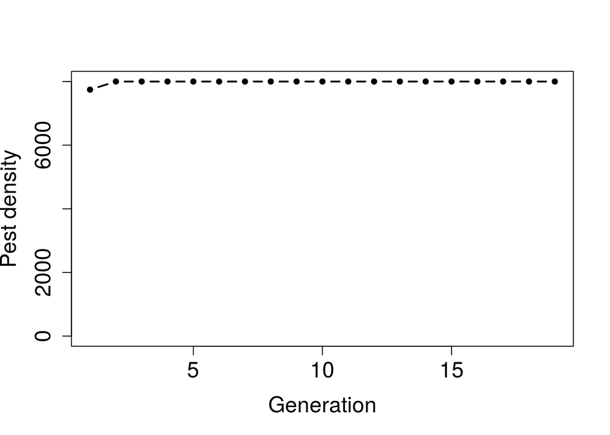

```r
sim1 <- toy_simulate_resistance(pathogens = 1, crops = 1, cell_K = 2000,
                                pest_init = 2000, fecundity = 8,
                                generations = 20, pest_move_pr = 0.1,
                                crop_rotate = "static", path_rotate = "static");
dat1 <- summarise_pest_data(sim1);
plot(x = 1:length(dat1), y = dat1, type = "b", pch = 20, lwd = 2, cex.lab = 1.5,
     cex.axis = 1.5, ylim = c(0, 8000), xlim = c(1, 19), xlab = "Generation",
     ylab = "Pest density");
```

Next, we can see what happens when we instead have 3 pathogens under otherwise identical conditions. In each generation, one of three pathogens is randomly applied to each landscape cell.

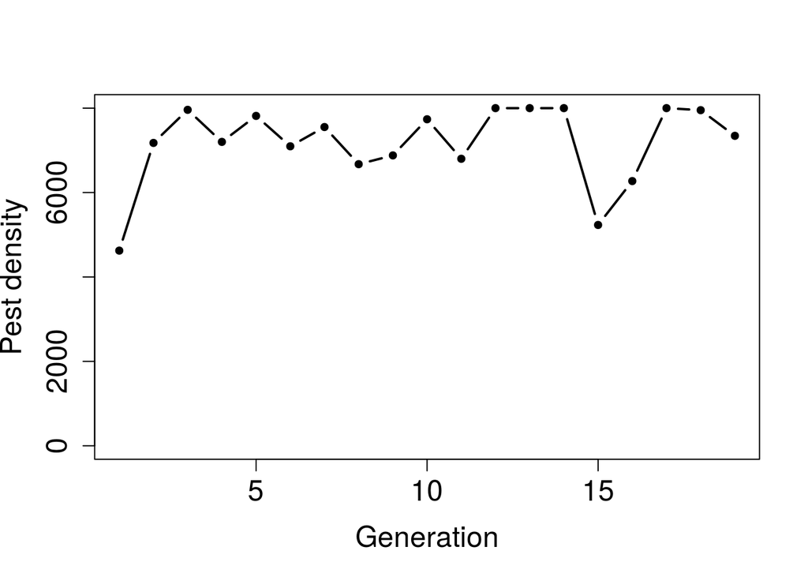

```r
sim2 <- toy_simulate_resistance(pathogens = 3, crops = 1, cell_K = 2000,
                                pest_init = 2000, fecundity = 8,
                                generations = 20, pest_move_pr = 0.1,
                                crop_rotate = "static", path_rotate = "random");
dat2 <- summarise_pest_data(sim2);
plot(x = 1:length(dat2), y = dat2, type = "b", pch = 20, lwd = 2, cex.lab = 1.5,
     cex.axis = 1.5, ylim = c(0, 8000), xlim = c(1, 19), xlab = "Generation",
     ylab = "Pest density");
```

Next, we can see what happens when we instead have 3 pathogens *and* 3 crops under otherwise identical conditions. In each generation, one of three pathogens and one of three crops are randomly applied to each landscape cell.

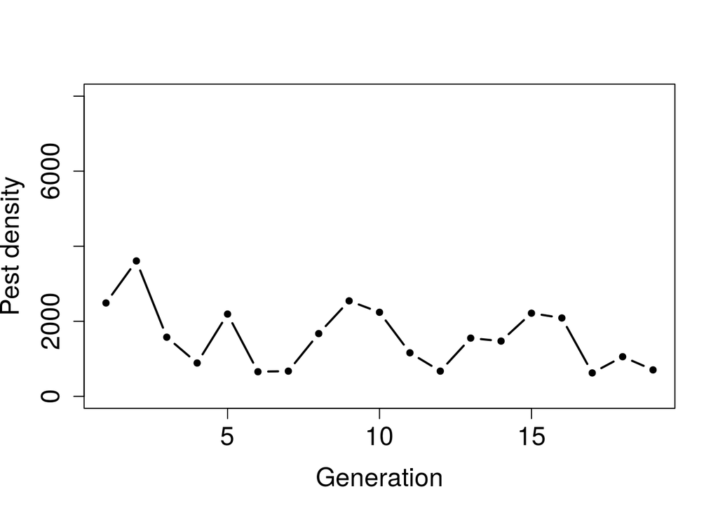

```r
sim3 <- toy_simulate_resistance(pathogens = 3, crops = 3, cell_K = 2000,
                                pest_init = 2000, fecundity = 8,
                                generations = 20, pest_move_pr = 0.1,
                                crop_rotate = "random", path_rotate = "random");
dat3 <- summarise_pest_data(sim3);
plot(x = 1:length(dat3), y = dat3, type = "b", pch = 20, lwd = 2, cex.lab = 1.5,
     cex.axis = 1.5, ylim = c(0, 8000), xlim = c(1, 19), xlab = "Generation",
     ylab = "Pest density");
```

As is evident, pathogen and crop rotation decreases pest density. More on this later, including diversity results, but this demonstrates a working toy model. As the heterogeneity of pathogens and crops increases, pest resistance seems to go down.

> Update: 30 JUL 2018

**Some general thoughts about code structure**

There are some high-level functions that will be useful to think about before coding; that is, functions that need to do something in sequence during simulation initialisation and then during each time step of the simulation. These functions will call subfunctions that run key routines – I think that all of these function, and the outer function (e.g., `simulate_resistance`, which runs through multiple time steps to test a particular set of parameter combinations), should be written in C for efficiency. An R function can call `simulate_resistance` and return the results to R, or an outer C function can also call it and print results to a text file (faster and easier with the computing cluster). The point is to have a single funtion that everything feeds to that does the work by calling multiple subfunctions – this workhorse function `simulate_resistance` will contain the main loop over $N$ `time_steps`.

Prior to the loop, there will be some initialisation of the landscape `LAND` and the pests `PEST`. This will include all of the values in each layer `LAND` based on parameter initialisation. The functions `initialise_land` and `initialise_pest` are therefore called once at the start of the simulation; they will need to decide the distribution of landscape values and pests, and the sizes of each. It will not be necessary to initialise the `PEST` traits, only their genomes (based on allele and loci parameters, dominance, etc.) and non-genetic attributes such as location and ID (sex might or might not be based on genome). Before starting the big loop, the key structures of `PEST` and `LAND` need to otherwise be built. Any other key data structures will need to be initialised – I am thinking that the `simulate_resistance` function, or maybe some small other function, should send a vector of information so that everything can be stored handily, then individual parameter values can be set in the small outer function then compiled into the vector for ease of use.

After initialisation, one big loop will run the simulation over multiple time steps (some pseudocode below).

```
simulate_resistance(parameter_values){
    error_checks(parameter_values);
    initialise_land(LAND);
    initialise_pest(PEST);
    for(time_step = 0; time_step < time_max; time_step++){
        build_pest_traits(PEST, build_type);
        set_crops(LAND, crop_parameters);
        set_biopesticide(LAND, biopesticide_parameters);
        move_pest(PEST, move_parameters);
        feed_pest(PEST, LAND, feeding_parameters);
        kill_pest(PEST, LAND, death_parameters);
        reproduce_pest(PEST, evolution_parameters);
        collect_PEST_data(PEST);
        collect_LAND_data(LAND);
        summarise_time_step(PEST, LAND);
        status_check(PEST, LAND);
    }
    summarise_simulation();
}
```

Multiple events will occur in each time step, including (but not limited to) the following: The `build_pest_traits()` function will simply read in and out the `PEST` array, building the traits from the pest genome according to some `build_type` in each generation. The `set_crops` function will assign `LAND` cel layer values basedon on the crop parameter values underlying, e.g., spatial heterogeneity; similarly, `set_biopesticide` will affect `LAND` cell layer values. Then the `move_pest` function will cause the pests to move according to some sort of disperal rules set in `parameter_values`. Note that the landscape and the pests have not interacted in the time step yet (though we can imagine the landscape affecting pest movement rules), and will now do so in `feed_pest`, where they will affect crops, followed by `kill_pest` and `reproduce_pest`, where they will suffer mortality and reproduce as a consequence of their interactions. **We might want to think about the order of these operations.** After pest reproduction (which will include sex and genetic – but not trait – transmission), then summary data on the pests and landscape need to be collected (could even have an option to print everything out at this point, but it might be a lot of information) – followed by a sort of grand summary of the time step. When the whole simulation has finished, then the results can be printed.

Note also that some error checks and status checks will be useful, since we’ll want to make this function able to run from R. The error checks will just make sure nothing will crash the simulation (some of this might be better programmed in R instead of C), while the `status_check` might look to see, e.g., if pests have gone extinct, or have some sort of rule for termination of the simulation if something happens.

I suspect that the above structure will need rearranging and rethinking, but it’s a starting point. Subfunctions will be the difficult part, coding efficient ways of building traits from the genome, movement rules, reproduction, etc.

> Update: 23 JUL 2018

I have attempted to set this notebook up with [Disqus](https://disqus.com/) commenting enabled with [the universal code options](https://helicoverpa.disqus.com/admin/install/platforms/universalcode/) (embedded HTML), which will ideally allow everyone on the project to make comments on the notes.

## Data structures

There are two data structures that we need to think about in particular, and these include the **pests**, which will be represented individually, and the **landscape**, which will be a large 3D array. The biopesticide will not be modelled discretely, but through a change in landscape values.

**Pests**

Pests will need to be represented by some sort of data structure. We could create a custom structure in C, but this would get messy if and when we decide to convert the model into an R package so that users can simulate by calling an R function. I really don’t see why pests cannot be represented by a large table, which is how I have always represented individuals in the past, and I already [have the code](https://github.com/bradduthie/gmse/blob/master/src/resource.c#L344) for reading R tables into C. The way that this will work then is to have each individual represented by a different row in the table, with columns corresponding to individual traits. Some traits that will be important include:

- Individual ID
- Sex (female or male)
- Traits 1-T: This includes traits such as dispersal ability, location (x and y), fecundity, and resistance to different biopesticides
- Loci 1-L: This will be a diploid system with allele values ($A^{v}_{i}$) and dominance coefficients $A^{h}_{v}$, the notation of which will likely change, but three `double` values will be used for each haploid loci: 1. allele number ($i$), value ($v$), and dominance ($h$). Since alleles are diploid, we will need $6L$ `double` columns in total, which will be the last columns of the table (this is just easier)

The idea of each individual having its own ID and sex is fairly straightforward, but what I’m thinking we can do with the traits will be a bit different. We want the evolving genome to affect resistance through a evolving traits, such that the genome affects traits underlying resistance, which then affect the evolution of the genetic architecture itself. The idea then is that each trait will be modelled as a `double` real number that is ‘visible’ to selection – in most cases we will want the value of each trait will be a function of the genome, but this wouldn’t necessarily be a requirement (e.g., if we just wanted to fix dispersal ability to some value, we could set it to whatever we desire in the relevant row and column – this will also be useful for location on the landscape, which will be represented by two values x and y). We could then write a specific modular function `build_traits`, which loops through each individual and derives a single number from the individual’s genome, which is then placed in the relevant trait column (1-T). Trait columns can by dynamic – we can have anywhere from 1 to T of them, and the value of T will need to be stored somewhere – better, if in the code we define ID and Sex as traits, we can just have loci start at T (or T + 1 in R).

By having a modular `build_traits` function, we can keep the code flexible enough to have different ways of deriving single trait values for any given genome. The genome itself is probably easiest to model by breaking it down into L blocks of six, taking up 6L total columns of the 2D **pest** array. The first three values of a block will be the number (1), value (2), and dominance (3) for an allele, while the next three values will be the same for a homologous allele at the locus. The dominance values could be compared to calculate which allele has a stronger effect, similar to Duthie and Reid (2016 [code](https://github.com/bradduthie/Inbreeding)), and this could be pre-set or randomised in some way for different allele types. The values could mean whatever we want them to, but a good starting point would be to think of them as additively effecting one or more trait as in Duthie et al. (2018 [code](https://github.com/bradduthie/pre_post_cop)). We could of course just have the allele numbers in the genome, with a separate lookup table to match them with values and dominance coefficients, but I actually think this would be slower and more difficult to code. The `build_traits` function will loop through all of the loci, gathering in the relevant values to build each trait – a sub-function (e.g., `calc_trait`) could do this for an individual trait, identifying where and what in the genome should be used to make a single trait such as resistance to a particular biopesticide. So, for example, the pest data structure for one (non ID or Sex) trait and one locus would look like this:

```r
simple_pests <- matrix(data = 0, nrow = 4, ncol = 9);
colnames(simple_pests) <- c("ID", "Sex", "Trait_1", "L1A1_i", "L1A1_v",
                            "L1A1_h", "L1A2_i", "L1A2_v", "L1A2_h");
simple_pests[,1] <- 1:4;
simple_pests[,2] <- c(0, 1, 0, 1);
simple_pests[,3] <- runif(n = 4);
simple_pests[,4] <- sample(x = 1:2, size = 4, replace = TRUE);
simple_pests[,7] <- sample(x = 1:2, size = 4, replace = TRUE);
print(simple_pests);
```

```
##      ID Sex   Trait_1 L1A1_i L1A1_v L1A1_h L1A2_i L1A2_v L1A2_h
## [1,]  1   0 0.9575966      1      0      0      2      0      0
## [2,]  2   1 0.5234401      1      0      0      1      0      0
## [3,]  3   0 0.8757418      1      0      0      1      0      0
## [4,]  4   1 0.2472505      1      0      0      1      0      0
```

I’ve not included the allele values or dominance coefficients for alleles 1 and 2. Note that in the columns ‘L1’ refers to locus 1, and ‘A1’ and ‘A2’ refer to alleles 1 and 2, respectively. As mentioned earlier, these will need to be represented by doubles in C, and the table could get quite big (well over 1000 columns, and potentially tens of thousands of rows). The benefit of doing all this is that we can potentially use multiple different types of infection models, as desired (e.g., gene for gene, quantative, threshold).

**Landscape**

The landscape will be modelled using a three dimensional array. We want space to be explicit, and the easiest way to do this is to have the first two dimensions of the array correspond to the x and y locations on a region of landscape. Interactions can happen at the scale of landscape cells (array elements), and distance between cells in any location can allow for explicit spatial processes (typically, count the number of cells in any of 8 directions, including diagonally, but other neighbour distances could be used, or cells could be hexagonal if there is good reason to do it). Having different cells with different values allows for landscape level heterogeneity (could also make values autocorrelated as desired as in Duthie and Falcy (2013)). Perhaps each cell starts with having some ID for the farm, as in the case of the 8 by 8 landscape below (actually x and y dimensions will be a variable in the model – I usually use 100 by 100, with a torus landscape that wraps around itself to avoid edge effects).

```r
land_IDs <- matrix(data = 0, nrow = 8, ncol = 8);
land_IDs[1:2, 1:8] <- 1;
land_IDs[3:6, 1:5] <- 2;
land_IDs[3:8, 6:8] <- 3;
land_IDs[7:8, 1:3] <- 4;
land_IDs[7:8, 4:5] <- 5;
print(land_IDs);
```

```
##      [,1] [,2] [,3] [,4] [,5] [,6] [,7] [,8]
## [1,]    1    1    1    1    1    1    1    1
## [2,]    1    1    1    1    1    1    1    1
## [3,]    2    2    2    2    2    3    3    3
## [4,]    2    2    2    2    2    3    3    3
## [5,]    2    2    2    2    2    3    3    3
## [6,]    2    2    2    2    2    3    3    3
## [7,]    4    4    4    5    5    3    3    3
## [8,]    4    4    4    5    5    3    3    3
```

So each of five farms or types of farms (or something else) are represented in the landscape. But we need lots of pieces of information for each cell, including what is planted on the cell, local environmental variables, and biopesticide applied. To get this, we can then add multiple layers on the z axis of a 3D array. So the landscape layer above is just the ‘top’, with multiple layers beneath coding critical information in a `land` array. Assume, for now that we need three layers (we’ll actually need a lot more): (1) `land_IDs`, (2) crop used, (3) biopesticide 1 applied.

```r
land      <- array(data = 0, dim = c(8, 8, 3));
land[,,1] <- land_IDs;
land[,,2] <- sample(x = 1:3, size = 64, replace = TRUE);
land[,,3] <- round(x = runif(n = 64, min = 0, max = 1), digits = 3);
print(land);
```

```
## , , 1
##
##      [,1] [,2] [,3] [,4] [,5] [,6] [,7] [,8]
## [1,]    1    1    1    1    1    1    1    1
## [2,]    1    1    1    1    1    1    1    1
## [3,]    2    2    2    2    2    3    3    3
## [4,]    2    2    2    2    2    3    3    3
## [5,]    2    2    2    2    2    3    3    3
## [6,]    2    2    2    2    2    3    3    3
## [7,]    4    4    4    5    5    3    3    3
## [8,]    4    4    4    5    5    3    3    3
##
## , , 2
##
##      [,1] [,2] [,3] [,4] [,5] [,6] [,7] [,8]
## [1,]    1    2    3    1    1    1    1    1
## [2,]    1    3    3    2    3    3    1    3
## [3,]    2    2    1    3    1    2    2    3
## [4,]    1    1    1    2    1    1    3    2
## [5,]    2    3    2    1    3    3    3    3
## [6,]    2    3    3    3    1    1    1    3
## [7,]    2    2    1    2    1    2    3    1
## [8,]    1    1    3    3    2    3    2    3
##
## , , 3
##
##       [,1]  [,2]  [,3]  [,4]  [,5]  [,6]  [,7]  [,8]
## [1,] 0.941 0.491 0.078 0.312 0.021 0.150 0.459 0.936
## [2,] 0.269 0.683 0.000 0.885 0.805 0.820 0.973 0.143
## [3,] 0.870 0.204 0.927 0.742 0.781 0.248 0.961 0.084
## [4,] 0.461 0.616 0.105 0.870 0.451 0.036 0.290 0.110
## [5,] 0.967 0.115 0.718 0.030 0.032 0.014 0.900 0.827
## [6,] 0.514 0.740 0.869 0.841 0.198 0.434 0.802 0.086
## [7,] 0.619 0.178 0.895 0.783 0.215 0.328 0.119 0.323
## [8,] 0.161 0.890 0.524 0.787 0.113 0.379 0.947 0.251
```

The details aren’t so important for now; what matters is the idea that we can represent information about landscape cells dynamically using array layers, which can therefore correspond to any number of things that we want to affect pests. The above structures can be initialised in R and diverted to a toy model that could help accomplish the short-term goals of the project, but also diverted to C to do the more intense simulatoin involving complex genetic architecture (we’ll want a standalone C version too for speed and high-performance cluster computing). The toy model is probably the fist step – to have something loop over time steps showing that something (e.g., allelic diversity) is maintained under variable landscapes, but is not when landscapes are homogenous (or when dispersal is infinite). Probably best to simplify the genetics as much as possible (e.g., 1 locus, fewer than 5 alleles) for this, then return some numbers that can be extracted from these data structures to build a graphic.

I see these two structures (**PEST** and **LAND**) as being the two most important ones to get right early on because these are the ones that will be used in almost every part of the model. The code will otherwise be written modularly, meaning that if we don’t like the way that we’re, e.g., deriving pest traits from their genetic architecture, or setting dispersal rules, or modelling sex, then we can simply rewrite the specific function that does these things and plug it back into the model. With this, some list or vector is also needed to hold parameter values (**PARA**), at lesat from the transition from R to C.

> Update: 18 JUL 2018

I have now initialised this lab notebook for the helicoverpa R package and model.

## References

Duthie, A Bradley, Greta Bocedi, Ryan R Germain, and Jane M Reid. 2018. “Evolution of pre-copulatory and post-copulatory strategies of inbreeding avoidance and associated polyandry.” *Journal of Evolutionary Biology*. https://doi.org/10.1111/jeb.13189.

Duthie, A Bradley, and Matthew R Falcy. 2013. “The influence of habitat autocorrelation on plants and their seed-eating pollinators.” *Ecological Modelling* 251: 260–70. https://doi.org/10.1016/j.ecolmodel.2012.12.019.

Duthie, A Bradley, and Jane M Reid. 2016. “Evolution of inbreeding avoidance and inbreeding preference through mate choice among interacting relatives.” *American Naturalist* 188 (6): 000–000. https://doi.org/10.1086/688919.